# Assignment_04_1786343

```python
import pandas as pd
import numpy as np
import seaborn as sns
import matplotlib.pyplot as plt
import scipy.stats as st
import os
```

```python
customer_data = pd.read_csv('04_Assignment_data_extended.csv', delimiter = ";")
```

```python
customer_data.head()
```

|  | ID | Year_of_Birth | Highest_Qualification | Marital_Status | Income | Kids_home | Teen_home | AcceptedCmp3 | AcceptedCmp4 | AcceptedCmp5 | AcceptedCmp1 | AcceptedCmp2 | Complains | No._WebPurchases | No._CatalogPurchases | No._StorePurchases | Revenue |
| --- | --- | --- | --- | --- | --- | --- | --- | --- | --- | --- | --- | --- | --- | --- | --- | --- | --- |
| 0 | 5524 | 1957 | Graduation | Single | 58138.0 | 0 | 0 | 0 | 0 | 0 | 0 | 0 | 0 | 8 | 10 | 4 | 1617 |
| 1 | 2174 | 1954 | Graduation | Single | 46344.0 | 1 | 1 | 0 | 0 | 0 | 0 | 0 | 0 | 1 | 1 | 2 | 27 |
| 2 | 4141 | 1965 | Graduation | Together | 71613.0 | 0 | 0 | 0 | 0 | 0 | 0 | 0 | 0 | 8 | 2 | 10 | 776 |
| 3 | 6182 | 1984 | Graduation | Together | 26646.0 | 1 | 0 | 0 | 0 | 0 | 0 | 0 | 0 | 2 | 0 | 4 | 53 |
| 4 | 5324 | 1981 | PhD | Married | 58293.0 | 1 | 0 | 0 | 0 | 0 | 0 | 0 | 0 | 5 | 3 | 6 | 422 |

Nach dem Einlesen der Datei wird der Datensatz zunächst auf fehlende Werte untersucht und, falls vorhanden, entfernt.

```python
customer_data.isna().sum()
```

```
ID                        0
Year_of_Birth             0
Highest_Qualification     0
Marital_Status            0
Income                   24
Kids_home                 0
Teen_home                 0
AcceptedCmp3              0
AcceptedCmp4              0
AcceptedCmp5              0
AcceptedCmp1              0
AcceptedCmp2              0
Complains                 0
No._WebPurchases          0
No._CatalogPurchases      0
No._StorePurchases        0
Revenue                   0
dtype: int64
```

```python
customer_data = customer_data.dropna()
```

Danach werden noch die Punkte in einigen Spaltennamen entfernt, damit es leichter ist mit ihnen Berechnungen durchzuführen.

```python
customer_data = customer_data.rename(columns={'No._WebPurchases' : 'No_WebPurchases', 'No._CatalogPurchases': 'No_CatalogPurchases', 'No._StorePurchases': 'No_StorePurchases' })
```

### Aufgabe 1

Which five attributes does the revenue correlate with most strongly? Is this correlation significant? Give the correlation coefficient and the p-value as a number and interpret the result.

Um dies herauszufinden wird zunächst für alle Werte die Korrelation berechnet und mit Hilfe einer Heat Map dargestellt.

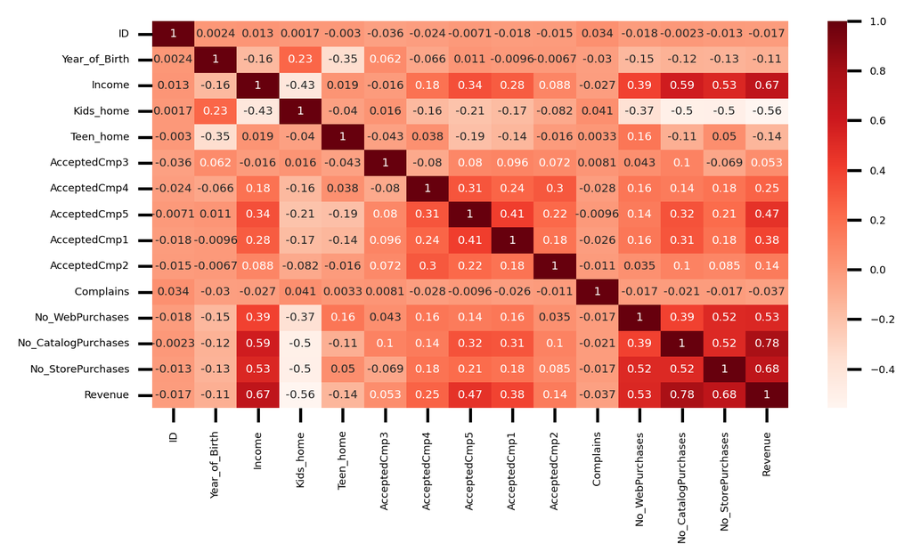

```python
plt.figure(figsize=(6,3), dpi = 300)
sns.set_context("notebook", font_scale=0.4)
sns.heatmap(customer_data.corr(), annot=True, cmap="Reds")
```

Laut der Heatmap haben die Attribute Income, No._StorePurchases, No._CatalogPurchases, No._WebPurchases, und AcceptedCmp5 die stärkste Korrelation mit der Revenue. Die stärkste negative Korrelation hat Kids_home. Um zu sehen, ob diese Ergebnisse signifikant sind (p < 0.05), wird als nächstes p berechnet.

```python
from scipy.stats import pearsonr
pearsonr(customer_data.Revenue, customer_data.Income)
```

```
(0.6675760903888279, 5.8439588064144495e-286)
```

Es gibt eine moderate positive Korrelation zwischen der Revenue und dem Einkommen des Kunden r = 0.67, p < 0.001.

```python
pearsonr(customer_data.Revenue, customer_data.No_CatalogPurchases)
```

```
(0.7804817805230357, 0.0)
```

Es gibt eine moderate positive Korrelation zwischen der Revenue und der Anzahl an Einkäufen über den Katalog des Kunden r = 0.78, p < 0.001.

```python
pearsonr(customer_data.Revenue, customer_data.No_StorePurchases)
```

```
(0.6751811032753723, 6.651615829181196e-295)
```

Es gibt eine moderate positive Korrelation zwischen der Revenue und der Anzahl an Store Einkäufen des Kunden r = 0.67, p < 0.001.

```python
pearsonr(customer_data.Revenue, customer_data.No_WebPurchases)
```

```
(0.5289733357135555, 4.9822802501716526e-160)
```

Es gibt eine moderate positive Korrelation zwischen der Revenue und der Anzahl an Web Einkäufen des Kunden r = 0.53, p < 0.001.

```python
pearsonr(customer_data.Revenue, customer_data.AcceptedCmp5)
```

```
(0.47027767215365085, 2.4479293615102445e-122)
```

```python
pearsonr(customer_data.Revenue, customer_data.Kids_home)
```

```
(-0.5578988410426331, 1.6433834344022126e-181)
```

### Aufgabe 2

Create and interpret a multiple regression model that explains the revenue. Explain and interpret the model. Describe what recommendations you can give the retailer, to increase the revenue.

Um möglichst sinnvolle Variablen für die Regression zu finden, werden zunächst einige Spalten als Scatterplot betrachtet, um ein besseres Gefühl für die Verteilung zu bekommen.

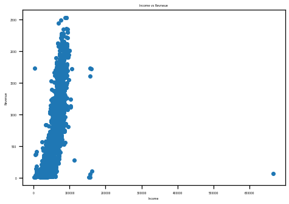

```python
fig=plt.figure()
ax1=fig.add_axes([0,0,1,1])
ax1.scatter(y="Revenue", x="Income", data= customer_data)
ax1.set_xlabel("Income")
ax1.set_ylabel("Revenue")
ax1.set_title("Income vs Revneue")
plt.show()
```

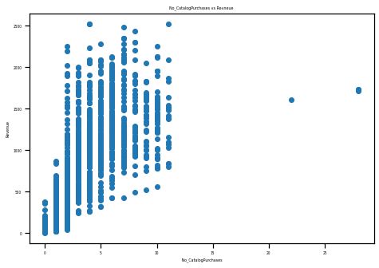

```python
fig=plt.figure()
ax2=fig.add_axes([0,0,1,1])
ax2.scatter(y="Revenue", x="No_CatalogPurchases", data= customer_data)
ax2.set_xlabel(" No_CatalogPurchases")
ax2.set_ylabel("Revenue")
ax2.set_title("No_CatalogPurchases vs Revneue")
plt.show()
```

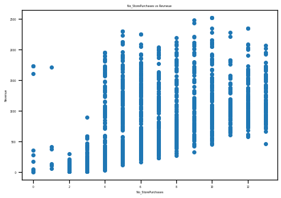

```python
fig=plt.figure()
ax3=fig.add_axes([0,0,1,1])
ax3.scatter(y="Revenue", x="No_StorePurchases", data= customer_data)
ax3.set_xlabel(" No_StorePurchases")
ax3.set_ylabel("Revenue")
ax3.set_title("No_StorePurchases vs Revneue")
plt.show()
```

Nun wird aus den 3 Merkmalen Income, No_CatalogPurchases und No_StorePurchases ein Regressionsmodell gebildet.

```python
import statsmodels.formula.api as smf
mdl_revenue_inc = smf.ols("Revenue ~ Income + No_CatalogPurchases + No_StorePurchases", data = customer_data).fit()
print(mdl_revenue_inc.params)
print(mdl_revenue_inc.summary())
```

```
Intercept             -261.439196
Income                   0.005112
No_CatalogPurchases    102.345241
No_StorePurchases       56.549077
dtype: float64
                            OLS Regression Results
==============================================================================
Dep. Variable:                Revenue   R-squared:                       0.736
Model:                            OLS   Adj. R-squared:                  0.736
Method:                 Least Squares   F-statistic:                     2057.
Date:                Sun, 07 Aug 2022   Prob (F-statistic):               0.00
Time:                        14:43:26   Log-Likelihood:                -15854.
No. Observations:                2216   AIC:                         3.172e+04
Df Residuals:                    2212   BIC:                         3.174e+04
Df Model:                           3
Covariance Type:            nonrobust
=======================================================================================
                          coef    std err          t      P>|t|      [0.025      0.975]
---------------------------------------------------------------------------------------
Intercept            -261.4392     16.649    -15.703      0.000    -294.088    -228.790
Income                  0.0051      0.000     14.937      0.000       0.004       0.006
No_CatalogPurchases   102.3452      2.919     35.057      0.000      96.620     108.070
No_StorePurchases      56.5491      2.503     22.590      0.000      51.640      61.458
==============================================================================
Omnibus:                      419.977   Durbin-Watson:                   1.981
Prob(Omnibus):                  0.000   Jarque-Bera (JB):             8244.420
Skew:                           0.319   Prob(JB):                         0.00
Kurtosis:                      12.428   Cond. No.                     1.47e+05
==============================================================================

Notes:
[1] Standard Errors assume that the covariance matrix of the errors is correctly specified.
[2] The condition number is large, 1.47e+05. This might indicate that there are
strong multicollinearity or other numerical problems.
```

Dem Retailer ist damit zu empfehlen Kunden aus einkommenstarken Gruppen auszubauen und dafür vielleicht auch ein paar hochpreisigere Produkte mit ins Sortiment zu nehmen. Außerdem sollte der Einkauf aus dem Katalog und der Einkaum im Geschäft so ansprechend wie möglich gestaltet werden.

### Aufgabe 3

Try to improve the model

Um das Model zu verbessern fügen wir eine neue Variable Kids_home und gleichzeitig auch noch Interaktion zwischen Einkommen und der Variable hinzu. Dafür visualisieren wir zunächst den Sachverhalt und sehen dabei, dass die Revenue weniger wird, je mehr Kinder ein Kunde hat.

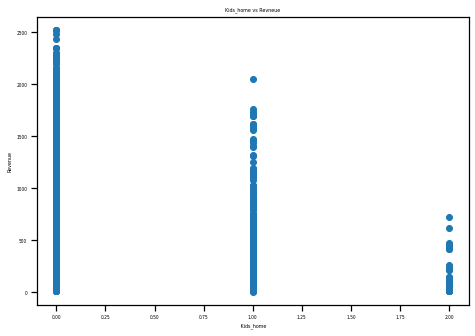

```python
fig=plt.figure()
ax4=fig.add_axes([0,0,1,1])
ax4.scatter(y="Revenue", x="Kids_home", data= customer_data)
ax4.set_xlabel(" Kids_home")
ax4.set_ylabel("Revenue")
ax4.set_title("Kids_home vs Revneue")
plt.show()
```

```python
mdl_revenue_inc_2 = smf.ols("Revenue ~ Income + No_CatalogPurchases + No_StorePurchases + Kids_home  + Income:Kids_home", data = customer_data).fit()
print(mdl_revenue_inc_2.params)
print(mdl_revenue_inc_2.summary())
```

```
Intercept             -423.238142
Income                   0.010967
No_CatalogPurchases     77.459810
No_StorePurchases       47.003564
Kids_home              288.622038
Income:Kids_home        -0.008661
dtype: float64
                            OLS Regression Results
==============================================================================
Dep. Variable:                Revenue   R-squared:                       0.764
Model:                            OLS   Adj. R-squared:                  0.764
Method:                 Least Squares   F-statistic:                     1432.
Date:                Sun, 07 Aug 2022   Prob (F-statistic):               0.00
Time:                        15:48:29   Log-Likelihood:                -15730.
No. Observations:                2216   AIC:                         3.147e+04
Df Residuals:                    2210   BIC:                         3.151e+04
Df Model:                           5
Covariance Type:            nonrobust
=======================================================================================
                          coef    std err          t      P>|t|      [0.025      0.975]
---------------------------------------------------------------------------------------
Intercept            -423.2381     28.077    -15.074      0.000    -478.298    -368.178
Income                  0.0110      0.001     20.542      0.000       0.010       0.012
No_CatalogPurchases    77.4598      3.161     24.506      0.000      71.261      83.658
No_StorePurchases      47.0036      2.488     18.895      0.000      42.125      51.882
Kids_home             288.6220     31.017      9.305      0.000     227.796     349.448
Income:Kids_home       -0.0087      0.001    -14.359      0.000      -0.010      -0.007
==============================================================================
Omnibus:                      312.700   Durbin-Watson:                   1.987
Prob(Omnibus):                  0.000   Jarque-Bera (JB):             1793.646
Skew:                           0.527   Prob(JB):                         0.00
Kurtosis:                       7.280   Cond. No.                     3.90e+05
==============================================================================

Notes:
[1] Standard Errors assume that the covariance matrix of the errors is correctly specified.
[2] The condition number is large, 3.9e+05. This might indicate that there are
strong multicollinearity or other numerical problems.
```

Das Hinzufügen von Interaktion verbessert das Model ein wenig - nämlich auf R-squared von 76 %. Das Model ist weiterhin statistisch signifikant (p < 0.0001).